```python
import seaborn as sns
sns.set_style("whitegrid")
```

# Introduction to the Course

### MGMT 638: Data-Driven Investments: Equity

### Kerry Back, Rice University

- Idea + data $\rightarrow$ backtest
- Look-ahead bias: can we reasonably backtest the strategy "buy electric car companies whose name starts with T?"
- parameters to this strategy: type of company, first letter of name
- We can backtest in a loop, updating once per year for example:
  - Find the type of company and the first letter of name that did best in the past $n$ years
  - Buy that company and hold for a year
  - Update each year: find the new best company/first letter and hold it for a year
- We have data on past prices and company financial statements (also more, but we won't get to it)
- We can code (ChatGPT can maybe help) to write backtest routines
- Create visualizations to compare strategies and write reports (ChatGPT can help)

### Elements of tests

- Past average return
- Sharpe ratio
- CAPM alpha and information ratio
- Fama-French alpha and information ratio
- Maximum drawdown
- Transactions costs (including shorting fees)
- Correlation with other strategies
- Tracking error relative to a benchmark

### Universe of stocks

- Large cap or small cap or mid cap or some of all?
- Industries: do we want to bet on industries or match industry weights to a benchmark?
- Value vs growth, etc.
- Our goal could be to find the best possible strategy without any constraints or we might be constrained to find the best strategy within mid-cap energy, for example.
- Different strategies may work better or worse depending on the universe of stocks we can consider.

### Get data from Yahoo Finance

```python
import yfinance as yf
import pandas as pd


data = yf.download('TSLA', start="1970-01-01")["Adj Close"]
data = pd.DataFrame(data)
data.columns = ["price"]
data.head()
```

```
[*********************100%***********************]  1 of 1 completed
```

| Date | price |
| --- | --- |
| 2010-06-29 00:00:00-04:00 | 1.592667 |
| 2010-06-30 00:00:00-04:00 | 1.588667 |
| 2010-07-01 00:00:00-04:00 | 1.464000 |
| 2010-07-02 00:00:00-04:00 | 1.280000 |
| 2010-07-06 00:00:00-04:00 | 1.074000 |

### Compute moving averages

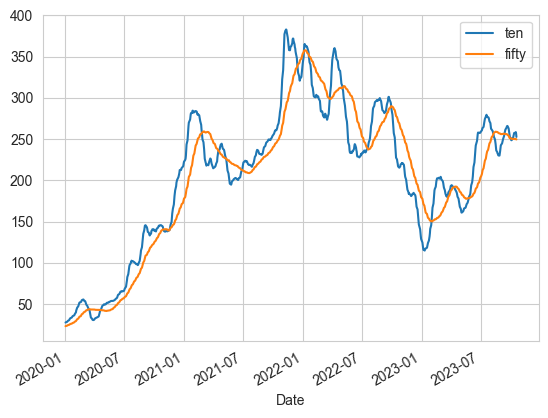

```python
data["ten"] = data.price.rolling(10).mean()
data["fifty"] = data.price.rolling(50).mean()
data[["ten", "fifty"]].loc["2020-01-01":].plot()
```

### Compute returns and lag moving averages

```python
data[["ten", "fifty"]] = data[["ten", "fifty"]].shift()
data["ret"] = data.price.pct_change()
data = data.dropna()
data.head()
```

| Date | price | ten | fifty | ret |
| --- | --- | --- | --- | --- |
| 2010-09-09 00:00:00-04:00 | 1.380667 | 1.351333 | 1.322240 | -0.009090 |
| 2010-09-10 00:00:00-04:00 | 1.344667 | 1.356733 | 1.318000 | -0.026074 |
| 2010-09-13 00:00:00-04:00 | 1.381333 | 1.359533 | 1.313120 | 0.027268 |
| 2010-09-14 00:00:00-04:00 | 1.408000 | 1.366333 | 1.311467 | 0.019305 |
| 2010-09-15 00:00:00-04:00 | 1.465333 | 1.374667 | 1.314027 | 0.040719 |

### Compute trade indicator

```python
data["long"] = data.ten < data.fifty
data.head()
```

| Date | price | ten | fifty | ret | long |
| --- | --- | --- | --- | --- | --- |
| 2010-09-09 00:00:00-04:00 | 1.380667 | 1.351333 | 1.322240 | -0.009090 | False |
| 2010-09-10 00:00:00-04:00 | 1.344667 | 1.356733 | 1.318000 | -0.026074 | False |
| 2010-09-13 00:00:00-04:00 | 1.381333 | 1.359533 | 1.313120 | 0.027268 | False |
| 2010-09-14 00:00:00-04:00 | 1.408000 | 1.366333 | 1.311467 | 0.019305 | False |
| 2010-09-15 00:00:00-04:00 | 1.465333 | 1.374667 | 1.314027 | 0.040719 | False |

### Compute returns of moving average strategy

```python
data["ma_ret"] = data.long * data.ret
data.head()
```

| Date | price | ten | fifty | ret | long | ma_ret |
| --- | --- | --- | --- | --- | --- | --- |
| 2010-09-09 00:00:00-04:00 | 1.380667 | 1.351333 | 1.322240 | -0.009090 | False | -0.0 |
| 2010-09-10 00:00:00-04:00 | 1.344667 | 1.356733 | 1.318000 | -0.026074 | False | -0.0 |
| 2010-09-13 00:00:00-04:00 | 1.381333 | 1.359533 | 1.313120 | 0.027268 | False | 0.0 |
| 2010-09-14 00:00:00-04:00 | 1.408000 | 1.366333 | 1.311467 | 0.019305 | False | 0.0 |
| 2010-09-15 00:00:00-04:00 | 1.465333 | 1.374667 | 1.314027 | 0.040719 | False | 0.0 |

### What tests do we want to do?

- Start by calculating average returns - multiply by 252 to annualize
- Then look at plot of compound returns - log scale works better for long time period
- Compute Sharpe ratios
- CAPM alphas, ...

### Mean returns

```python
print(f"buy and hold mean return is {252*data.ret.mean():.2%} annualized")
print(f"moving average mean return is {252*data.ma_ret.mean():.2%} annualized")
```

```
buy and hold mean return is 54.68% annualized
moving average mean return is 16.94% annualized
```

### Compound return plots

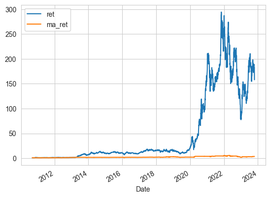

```python
(1+data[["ret", "ma_ret"]]).cumprod().plot()
```

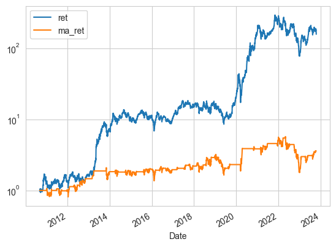

```python
(1+data[["ret", "ma_ret"]]).cumprod().plot(logy=True)
```

### Sharpe ratios

- Sharpe ratio is expected return minus risk-free rate / standard deviation
- We'll skip the risk-free rate
- Annualize mean return by multiplying by $252$
- Annualize variance by multiplying by $252$
- $\Rightarrow$ annualize standard deviation by multiplying by $\sqrt{252}$
- $\Rightarrow$ annualize Sharpe ratio by multiplying by $\sqrt{252}$

```python
import numpy as np
sharpe = np.sqrt(252) * (data.ret.mean() / data.ret.std())
ma_sharpe = np.sqrt(252) * (data.ma_ret.mean() / data.ma_ret.std())
print(f"Sharpe ratio of buy and hold strategy is {sharpe:.2%} annualized")
print(f"Sharpe ratio of moving average strategy is {ma_sharpe:.2%} annualized")
```

```
Sharpe ratio of buy and hold strategy is 96.35% annualized
Sharpe ratio of moving average strategy is 44.55% annualized
```

### Multiple stocks

```python
tickers = ["PG", "WMT", "CVX", "F", "MSFT"]
data = yf.download(tickers, start="2000-01-01")["Adj Close"]
data = pd.DataFrame(data.stack())
data.columns = ["price"]
data.index.names = ["date", "ticker"]
data.head()
```

```
[*********************100%***********************]  5 of 5 completed
```

| date | ticker | price |
| --- | --- | --- |
| 2000-01-03 00:00:00-05:00 | CVX | 17.508459 |
|  | F | 13.405164 |
|  | MSFT | 36.205597 |
|  | PG | 28.608192 |
|  | WMT | 43.717712 |

```python
data["ten"] = data.groupby("ticker", group_keys=False).price.apply(
    lambda x: x.rolling(10).mean()
)
data["fifty"] = data.groupby("ticker", group_keys=False).price.apply(
    lambda x: x.rolling(50).mean()
)
data["ten"] = data.groupby("ticker", group_keys=False).ten.shift()
data["fifty"] = data.groupby("ticker", group_keys=False).fifty.shift()
```

```python
data["ret"] = data.groupby("ticker", group_keys=False).price.pct_change()
data["long"] = data.ten > data.fifty
data["ma_ret"] = data.long * data.ret
data = data.dropna()
data.head()
```

| date | ticker | price | ten | fifty | ret | long | ma_ret |
| --- | --- | --- | --- | --- | --- | --- | --- |
| 2000-03-15 00:00:00-05:00 | CVX | 17.722534 | 16.635165 | 17.040949 | 0.012821 | False | 0.0 |
|  | F | 11.391672 | 10.794621 | 12.190062 | 0.074695 | False | 0.0 |
|  | MSFT | 29.624529 | 29.616764 | 31.569343 | 0.002628 | False | 0.0 |
|  | PG | 15.656404 | 18.598676 | 25.318128 | 0.049327 | False | 0.0 |
|  | WMT | 33.740608 | 32.119635 | 36.882368 | 0.079891 | False | 0.0 |

### Equally weighted returns

- Equally weighted strategies are never buy and hold, because with buy and hold weights increase on stocks that did relatively better.
- Value weighted is buy and hold.

```python
rets = data.groupby("date").ret.mean()
ma_rets = data.groupby("date").ma_ret.mean()

print(f"equally weighted mean return is {252*rets.mean():.2%} annuallized")
print(f"equally weighted moving average mean return is {252*ma_rets.mean():.2%} annualized")
```

```
equally weighted mean return is 11.78% annuallized
equally weighted moving average mean return is 5.72% annualized
```

### Exercise

Look at different sets of stocks and different moving averages and test strategies.